# Wybór zmiennych do raportu

Karolina Marcinkowska

20 maja 2018

# 1 Rozkład braków danych

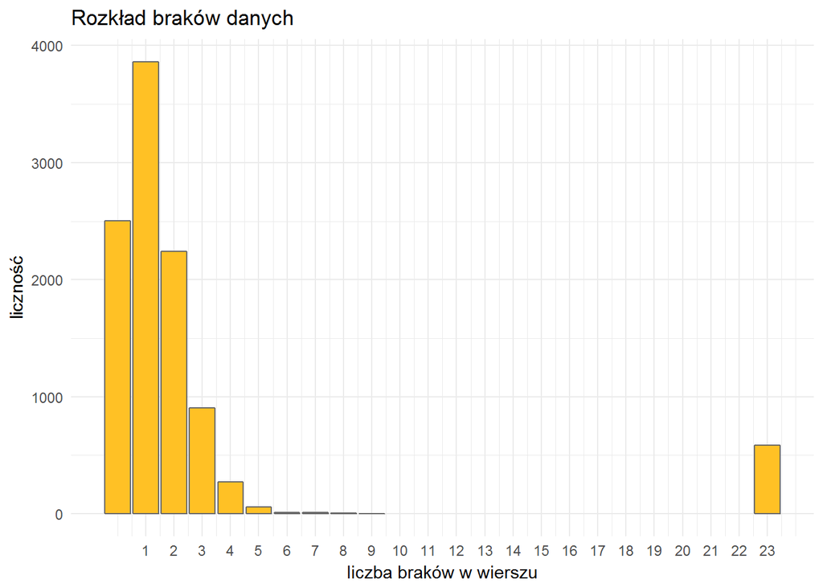

Jak można zauważyć, mamy tylko 588 obserwacji, które są całkowicie puste (tzn. nie posiadają żadnej informacji). Obserwacje te stanowią 5.6% całej ramki danych i zostają z niej usunięte. Kolejne etapy analizy dokonywane są na danych, które nie zawierają pustych wierszy.

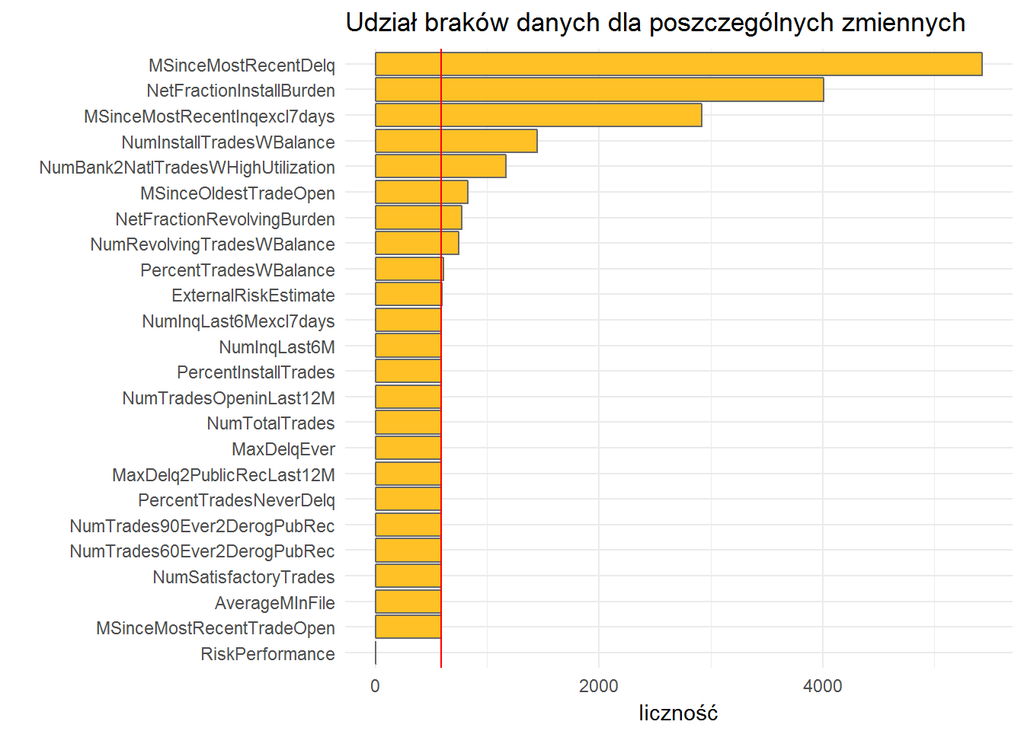

# 2 Rozkład zmiennej odpowiedzi

| wartość zmiennej | udział procentowy |
| --- | --- |
| Bad | 52.03 |
| Good | 47.97 |

Jak widać, zbiór jest zrównoważony pod względem wartości zmiennej odpowiedzi. Nie ma sytuacji, kiedy zmienna odpowiedzi nie przyjmuje żadnej wartości.

# 3 Zmienne objaśniające

Poniżej przedstawione zostały wykresy dla poszczególnych zmiennych objaśniających w postaci hisogramów oraz wyestymowanych na ich podstawie gęstości (dla zmiennych ciągłych), natomiast dla zmiennych dyskretnych przedstawione zostały jedynie wykresy słupkowe obrazujące liczności poszczególnych kategorii.

Zestawienie zostało przygotowane dla dwóch zestawów danych - przed uzupełnianiem braków i po. Zabieg ten został zastosowany po to, aby upewnić się, czy uzupełnienie danych nie zmieniło rozkładu wyjściowego zmiennej. W sytuacji, kiedy zmienna nie posiadała braków, narysowany został tylko jeden wykres.

## 3.1 ExternalRiskEstimate

| Min. | 1st Qu. | Median | Mean | 3rd Qu. | Max. | NA’s |
| --- | --- | --- | --- | --- | --- | --- |
| 33 | 64 | 72 | 72.06044 | 80 | 94 | 10 |

| Min. | 1st Qu. | Median | Mean | 3rd Qu. | Max. |
| --- | --- | --- | --- | --- | --- |
| 33 | 64 | 72 | 72.06322 | 80 | 94 |

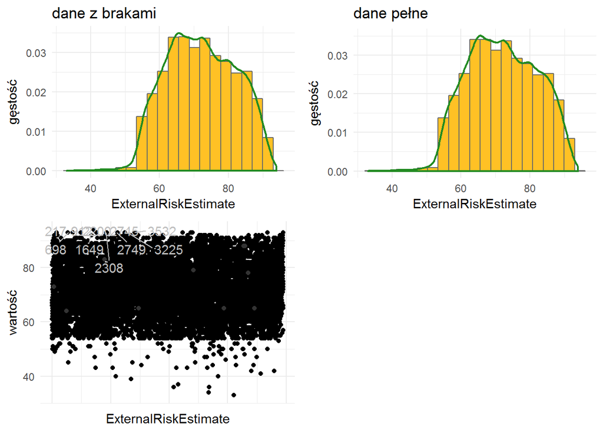

## 3.2 MSinceOldestTradeOpen

| Min. | 1st Qu. | Median | Mean | 3rd Qu. | Max. | NA’s |
| --- | --- | --- | --- | --- | --- | --- |
| 2 | 135 | 186 | 200.7691 | 257 | 803 | 239 |

| Min. | 1st Qu. | Median | Mean | 3rd Qu. | Max. |
| --- | --- | --- | --- | --- | --- |
| 2 | 134 | 185 | 200.1166 | 257 | 803 |

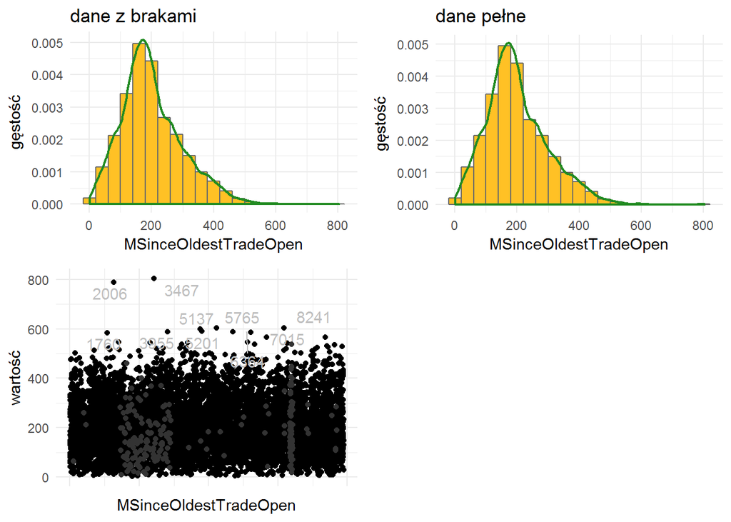

## 3.3 MSinceMostRecentTradeOpen

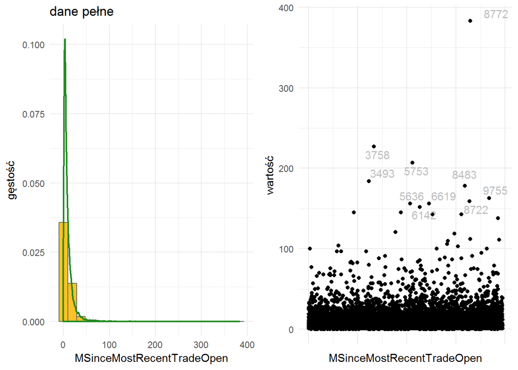

| Min. | 1st Qu. | Median | Mean | 3rd Qu. | Max. |
| --- | --- | --- | --- | --- | --- |
| 0 | 3 | 6 | 9.588491 | 12 | 383 |

## 3.4 AverageMInFile

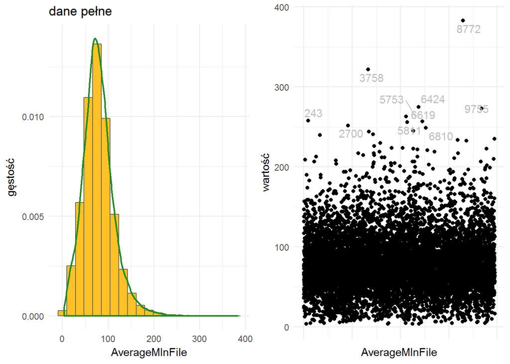

| Min. | 1st Qu. | Median | Mean | 3rd Qu. | Max. |
| --- | --- | --- | --- | --- | --- |
| 4 | 57 | 76 | 78.77814 | 97 | 383 |

## 3.5 NumSatisfactoryTrades

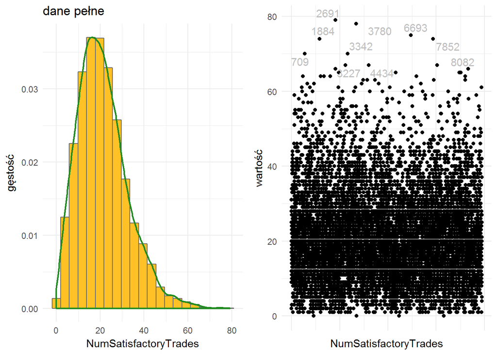

| Min. | 1st Qu. | Median | Mean | 3rd Qu. | Max. |
| --- | --- | --- | --- | --- | --- |
| 0 | 13 | 20 | 21.12147 | 28 | 79 |

## 3.6 NumTrades60Ever2DerogPubRec

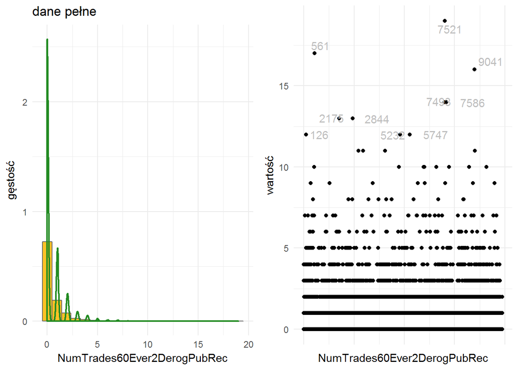

| Min. | 1st Qu. | Median | Mean | 3rd Qu. | Max. |
| --- | --- | --- | --- | --- | --- |
| 0 | 0 | 0 | 0.5814001 | 1 | 19 |

## 3.7 NumTrades90Ever2DerogPubRec

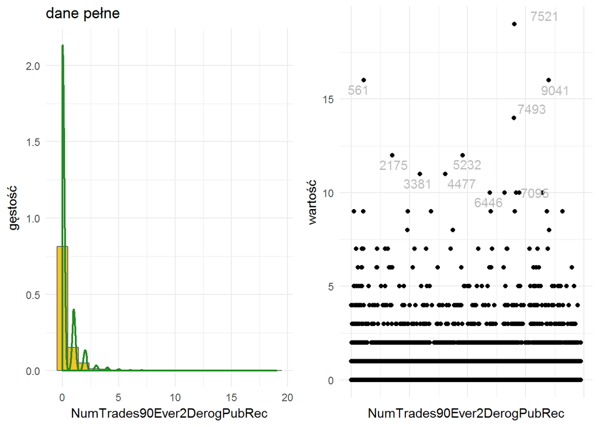

| Min. | 1st Qu. | Median | Mean | 3rd Qu. | Max. |
| --- | --- | --- | --- | --- | --- |
| 0 | 0 | 0 | 0.3847634 | 0 | 19 |

## 3.8 PercentTradesNeverDelq

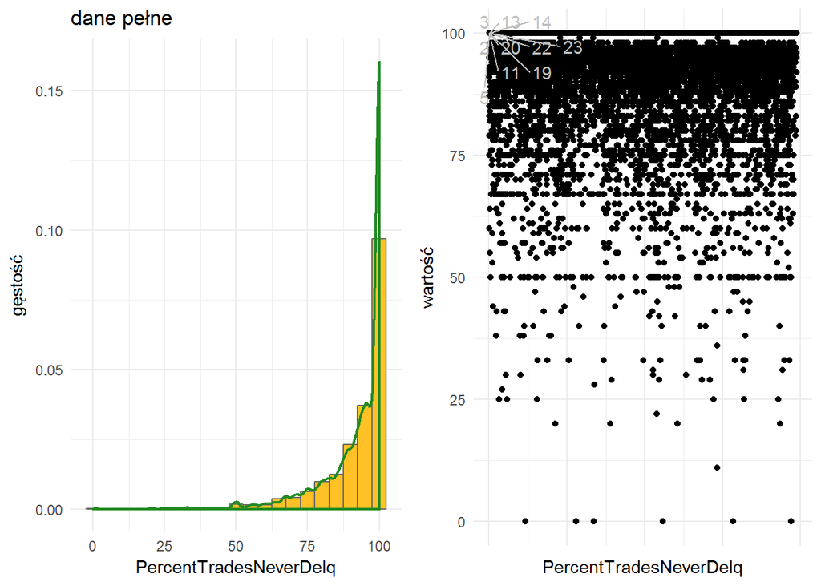

| Min. | 1st Qu. | Median | Mean | 3rd Qu. | Max. |
| --- | --- | --- | --- | --- | --- |
| 0 | 89 | 97 | 92.35994 | 100 | 100 |

## 3.9 MSinceMostRecentDelq

| Min. | 1st Qu. | Median | Mean | 3rd Qu. | Max. | NA’s |
| --- | --- | --- | --- | --- | --- | --- |
| 0 | 5 | 15 | 21.87955 | 34 | 83 | 4840 |

| Min. | 1st Qu. | Median | Mean | 3rd Qu. | Max. |
| --- | --- | --- | --- | --- | --- |
| 0 | 12 | 30 | 32.91531 | 51 | 83 |

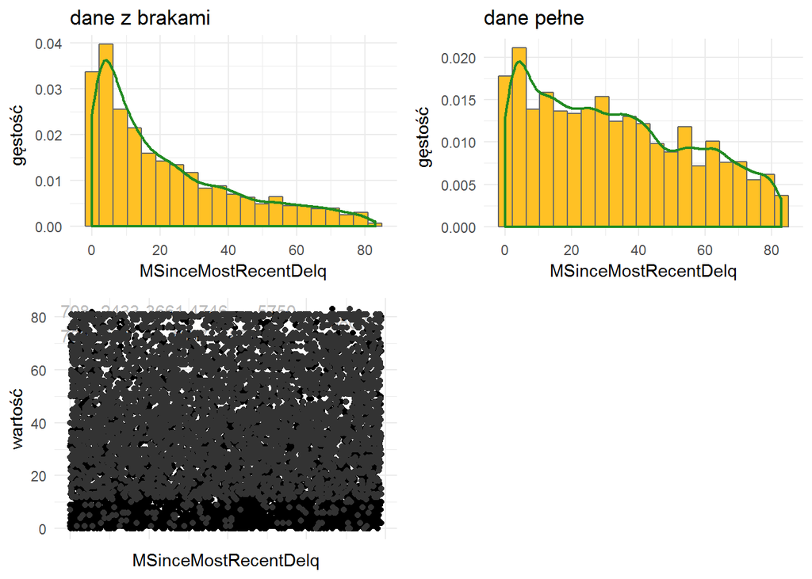

## 3.10 MaxDelq2PublicRecLast12M

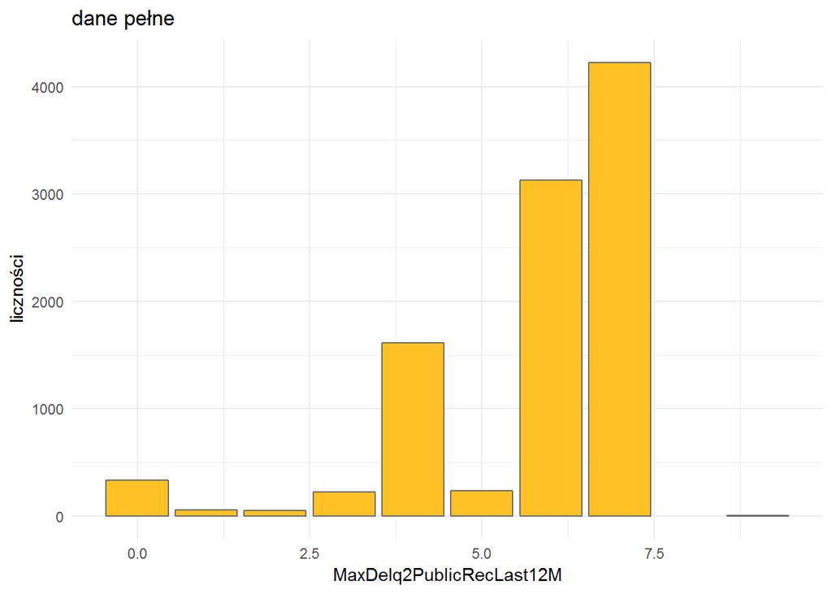

| Min. | 1st Qu. | Median | Mean | 3rd Qu. | Max. |
| --- | --- | --- | --- | --- | --- |
| 0 | 5 | 6 | 5.757978 | 7 | 9 |

## 3.11 MaxDelqEver

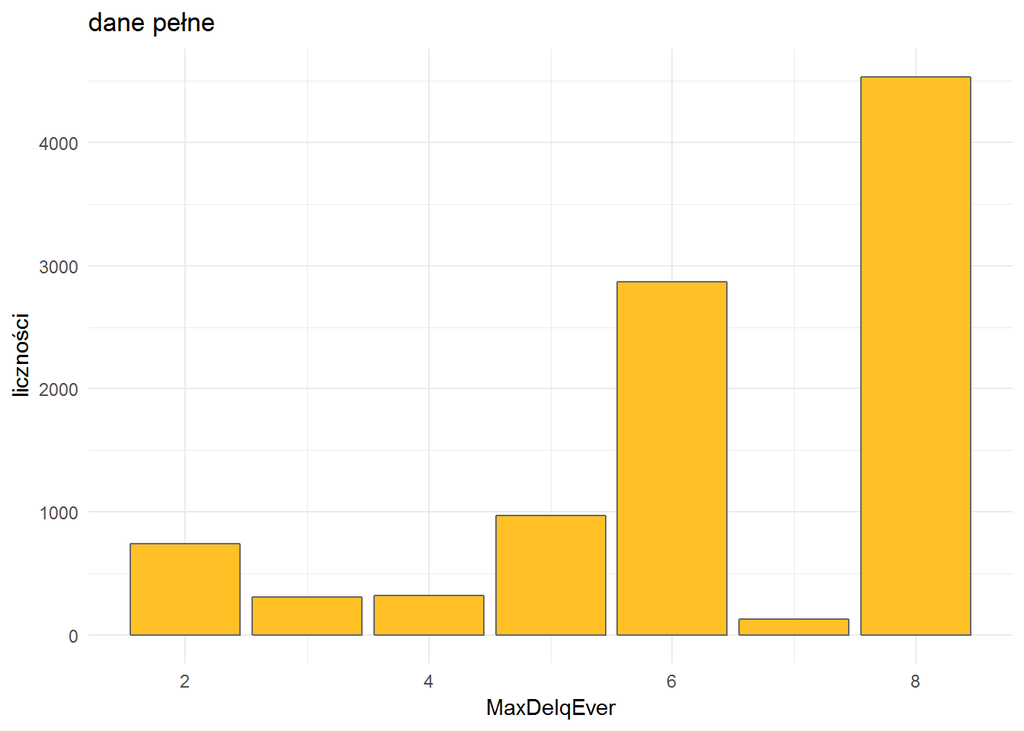

| Min. | 1st Qu. | Median | Mean | 3rd Qu. | Max. |
| --- | --- | --- | --- | --- | --- |
| 2 | 6 | 6 | 6.374531 | 8 | 8 |

## 3.12 NumTotalTrades

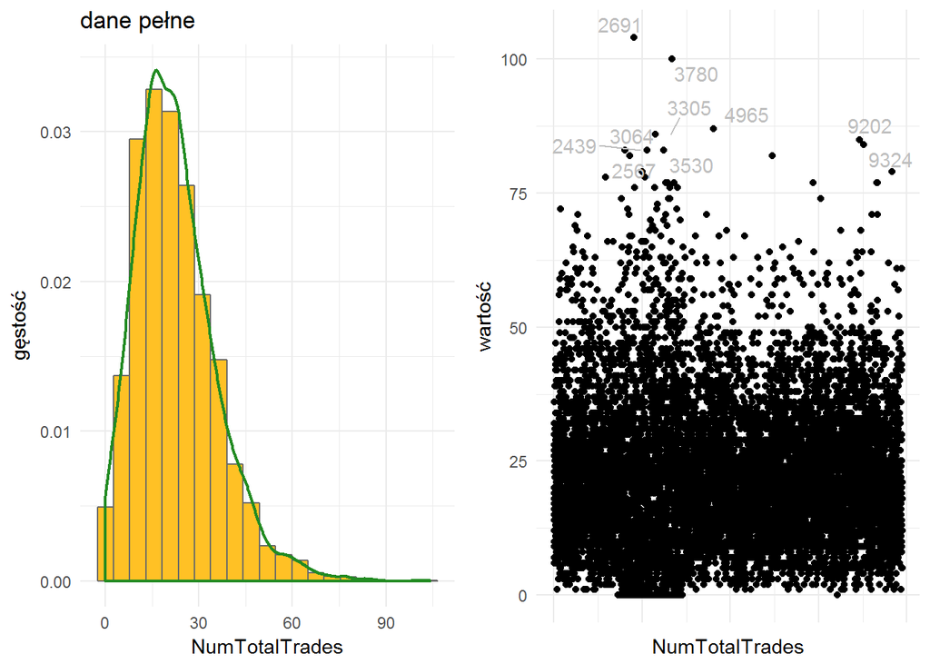

| Min. | 1st Qu. | Median | Mean | 3rd Qu. | Max. |
| --- | --- | --- | --- | --- | --- |
| 0 | 13 | 21 | 22.6355 | 30 | 104 |

## 3.13 NumTradesOpeninLast12M

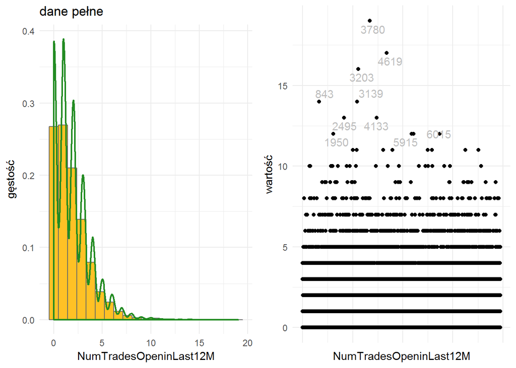

| Min. | 1st Qu. | Median | Mean | 3rd Qu. | Max. |
| --- | --- | --- | --- | --- | --- |
| 0 | 0 | 1 | 1.863844 | 3 | 19 |

## 3.14 PercentInstallTrades

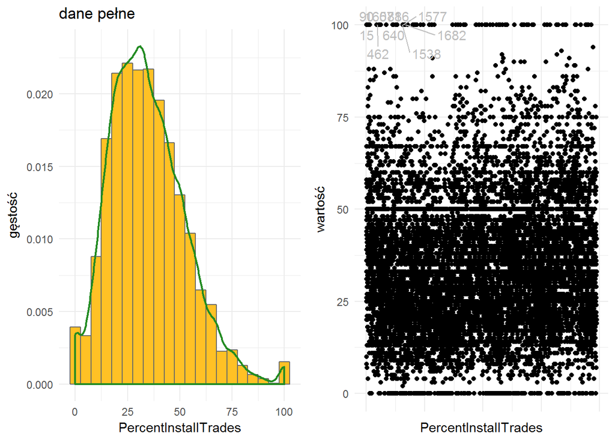

| Min. | 1st Qu. | Median | Mean | 3rd Qu. | Max. |
| --- | --- | --- | --- | --- | --- |
| 0 | 21 | 33 | 34.61868 | 45 | 100 |

## 3.15 MSinceMostRecentInqexcl7days

| Min. | 1st Qu. | Median | Mean | 3rd Qu. | Max. | NA’s |
| --- | --- | --- | --- | --- | --- | --- |
| 0 | 0 | 0 | 2.477719 | 3 | 24 | 2331 |

| Min. | 1st Qu. | Median | Mean | 3rd Qu. | Max. |
| --- | --- | --- | --- | --- | --- |
| 0 | 0 | 0 | 2.631142 | 3 | 24 |

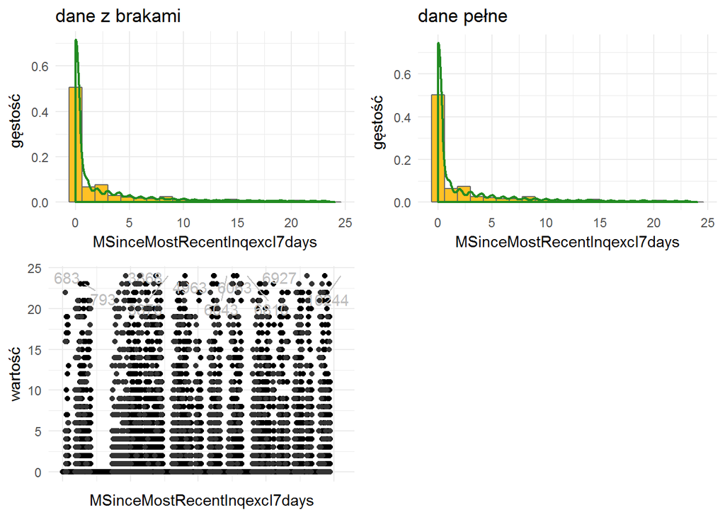

## 3.16 NumInqLast6M

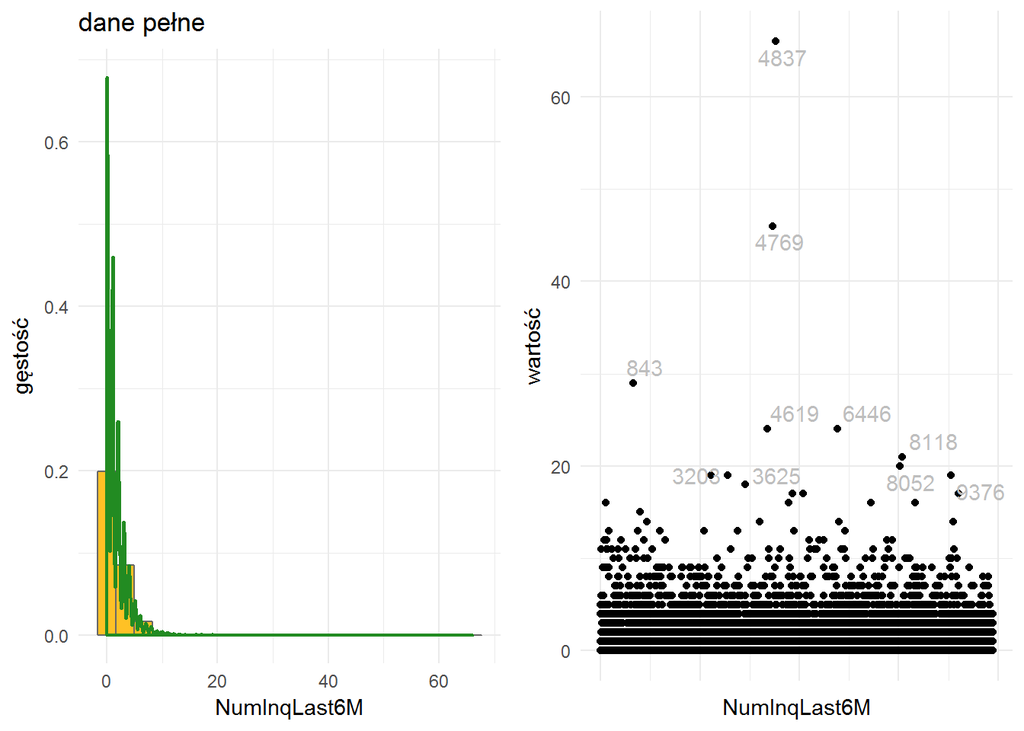

| Min. | 1st Qu. | Median | Mean | 3rd Qu. | Max. |
| --- | --- | --- | --- | --- | --- |
| 0 | 0 | 1 | 1.455982 | 2 | 66 |

## 3.17 NumInqLast6Mexcl7days

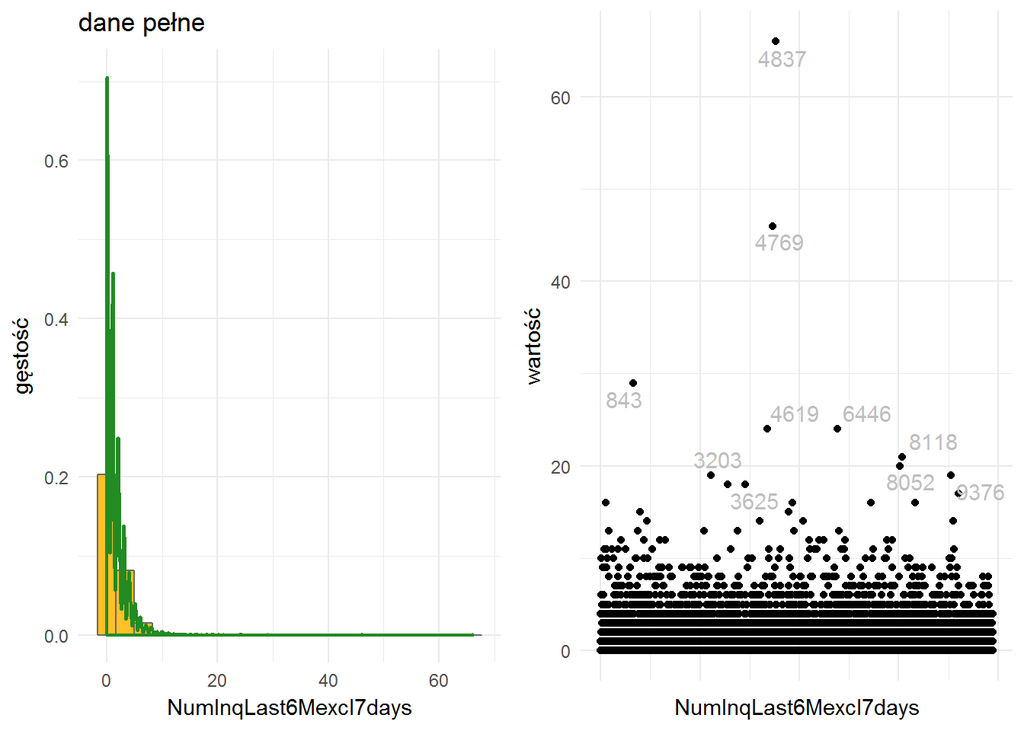

| Min. | 1st Qu. | Median | Mean | 3rd Qu. | Max. |
| --- | --- | --- | --- | --- | --- |
| 0 | 0 | 1 | 1.397123 | 2 | 66 |

## 3.18 NetFractionRevolvingBurden

| Min. | 1st Qu. | Median | Mean | 3rd Qu. | Max. | NA’s |
| --- | --- | --- | --- | --- | --- | --- |
| 0 | 9 | 29 | 34.85772 | 56 | 232 | 186 |

| Min. | 1st Qu. | Median | Mean | 3rd Qu. | Max. |
| --- | --- | --- | --- | --- | --- |
| 0 | 9 | 30 | 35.2713 | 57 | 232 |

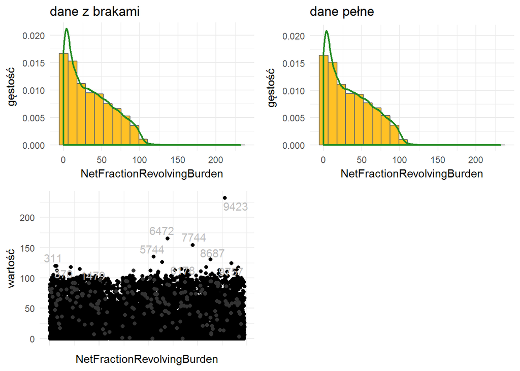

## 3.19 NetFractionInstallBurden

| Min. | 1st Qu. | Median | Mean | 3rd Qu. | Max. | NA’s |
| --- | --- | --- | --- | --- | --- | --- |
| 0 | 53 | 74 | 68.53797 | 87 | 471 | 3419 |

| Min. | 1st Qu. | Median | Mean | 3rd Qu. | Max. |
| --- | --- | --- | --- | --- | --- |
| 0 | 50 | 71 | 66.19228 | 86 | 471 |

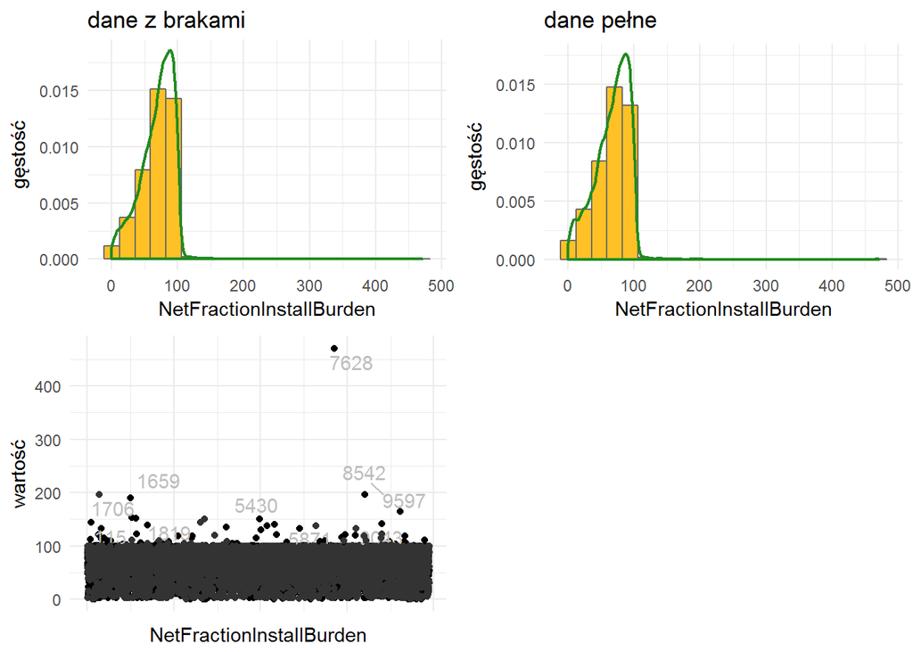

## 3.20 NumRevolvingTradesWBalance

| Min. | 1st Qu. | Median | Mean | 3rd Qu. | Max. | NA’s |
| --- | --- | --- | --- | --- | --- | --- |
| 0 | 2 | 3 | 4.10211 | 5 | 32 | 156 |

| Min. | 1st Qu. | Median | Mean | 3rd Qu. | Max. |
| --- | --- | --- | --- | --- | --- |
| 0 | 2 | 3 | 4.058758 | 5 | 32 |

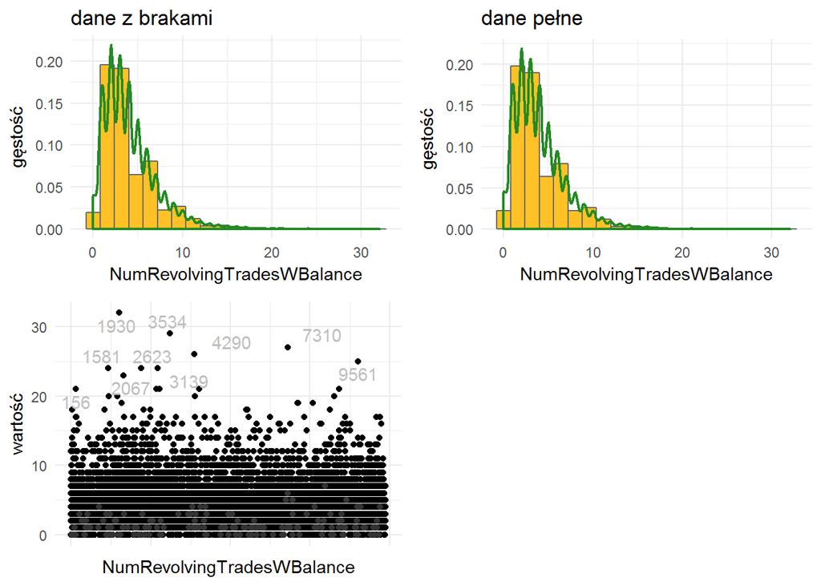

## 3.21 NumInstallTradesWBalance

| Min. | 1st Qu. | Median | Mean | 3rd Qu. | Max. | NA’s |
| --- | --- | --- | --- | --- | --- | --- |
| 1 | 1 | 2 | 2.484906 | 3 | 23 | 861 |

| Min. | 1st Qu. | Median | Mean | 3rd Qu. | Max. |
| --- | --- | --- | --- | --- | --- |
| 1 | 1 | 2 | 2.392463 | 3 | 23 |

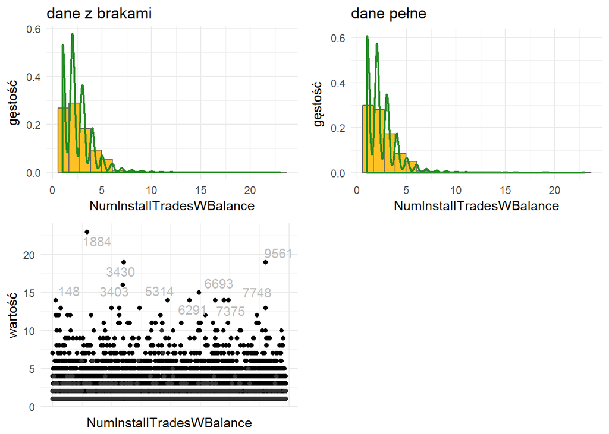

## 3.22 NumBank2NatlTradesWHighUtilization

| Min. | 1st Qu. | Median | Mean | 3rd Qu. | Max. | NA’s |
| --- | --- | --- | --- | --- | --- | --- |
| 0 | 0 | 1 | 1.09227 | 2 | 18 | 583 |

| Min. | 1st Qu. | Median | Mean | 3rd Qu. | Max. |
| --- | --- | --- | --- | --- | --- |
| 0 | 0 | 1 | 1.054807 | 2 | 18 |

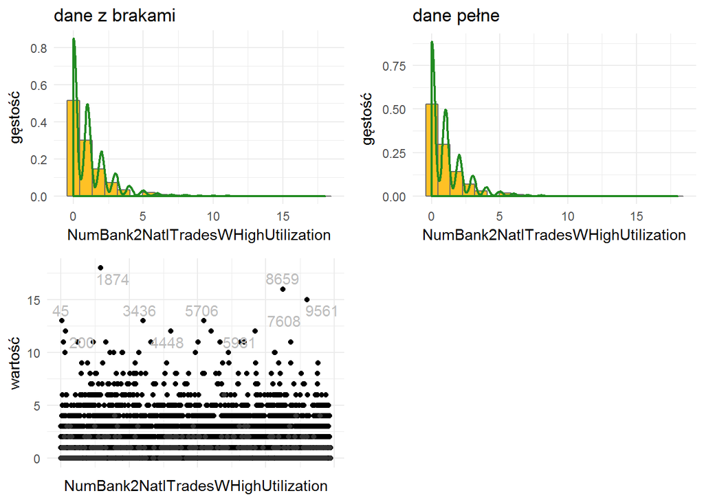

## 3.23 PercentTradesWBalance

| Min. | 1st Qu. | Median | Mean | 3rd Qu. | Max. | NA’s |
| --- | --- | --- | --- | --- | --- | --- |
| 0 | 50 | 67 | 66.449 | 83 | 100 | 18 |

| Min. | 1st Qu. | Median | Mean | 3rd Qu. | Max. |
| --- | --- | --- | --- | --- | --- |
| 0 | 50 | 67 | 66.4804 | 83 | 100 |

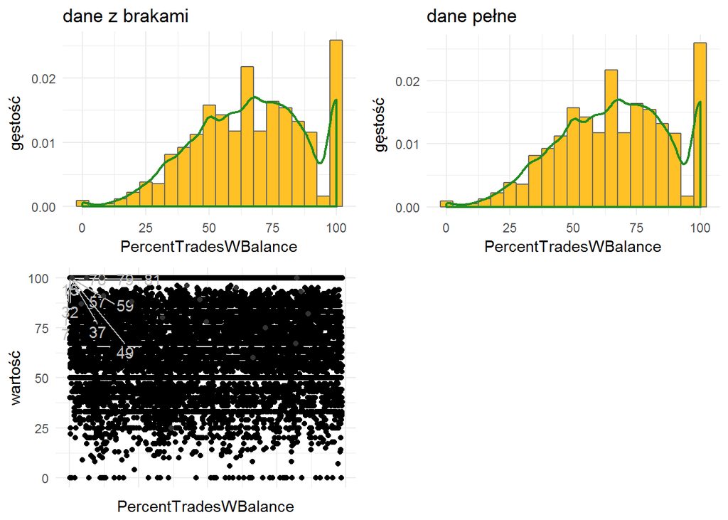

# 4 Obserwacje odstające

Poniższa tabela zawiera top10 obserwacji o największej wartości dla każdej zmiennej.

|  | x1 | x2 | x3 | x4 | x5 | x6 | x7 | x8 | x9 | x10 |
| --- | --- | --- | --- | --- | --- | --- | --- | --- | --- | --- |
| ExternalRiskEstimate | 1781 | 194 | 674 | 882 | 1230 | 1889 | 2325 | 2329 | 2804 | 3105 |
| MSinceOldestTradeOpen | 3040 | 1587 | 7713 | 5293 | 4696 | 4760 | 3526 | 5869 | 6514 | 1341 |
| MSinceMostRecentTradeOpen | 8232 | 3331 | 5281 | 3066 | 7953 | 9198 | 8189 | 5173 | 6123 | 5660 |
| AverageMInFile | 8232 | 3331 | 5929 | 9198 | 5281 | 220 | 6123 | 5338 | 2280 | 6312 |
| NumSatisfactoryTrades | 2271 | 3353 | 6196 | 1465 | 7342 | 685 | 2918 | 2806 | 4005 | 7557 |
| NumTrades60Ever2DerogPubRec | 7019 | 538 | 8498 | 6991 | 7084 | 1756 | 2424 | 115 | 4790 | 5275 |
| NumTrades90Ever2DerogPubRec | 7019 | 538 | 8498 | 6991 | 1756 | 4790 | 2956 | 4048 | 5951 | 6593 |
| PercentTradesNeverDelq | 2 | 3 | 5 | 11 | 13 | 14 | 19 | 20 | 22 | 23 |
| MSinceMostRecentDelq | 8324 | 684 | 736 | 759 | 2014 | 3234 | 3628 | 4315 | 4433 | 5278 |
| MaxDelq2PublicRecLast12M | 84 | 2243 | 5919 | 6027 | 8189 | 8605 | 3 | 5 | 11 | 14 |
| MaxDelqEver | 2 | 3 | 5 | 11 | 13 | 14 | 19 | 20 | 22 | 23 |
| NumTotalTrades | 2271 | 3353 | 4525 | 2881 | 8658 | 8774 | 2020 | 2644 | 3103 | 2147 |
| NumTradesOpeninLast12M | 3353 | 4189 | 2783 | 818 | 2719 | 2075 | 3704 | 1531 | 5436 | 5534 |
| PercentInstallTrades | 15 | 84 | 147 | 439 | 548 | 617 | 858 | 1119 | 1158 | 1263 |
| MSinceMostRecentInqexcl7days | 3439 | 3447 | 4523 | 5562 | 5582 | 6312 | 6427 | 9674 | 659 | 769 |
| NumInqLast6M | 4401 | 4337 | 818 | 4189 | 5951 | 7591 | 7530 | 2783 | 3198 | 8822 |
| NumInqLast6Mexcl7days | 4401 | 4337 | 818 | 4189 | 5951 | 7591 | 7530 | 2783 | 8822 | 3198 |
| NetFractionRevolvingBurden | 8867 | 5977 | 7239 | 5272 | 8155 | 5695 | 9200 | 288 | 347 | 1060 |
| NetFractionInstallBurden | 7126 | 8012 | 1240 | 9041 | 1287 | 1400 | 4973 | 107 | 8500 | 5397 |
| NumRevolvingTradesWBalance | 1511 | 3107 | 6808 | 3861 | 9005 | 1162 | 2203 | 2719 | 1648 | 143 |
| NumInstallTradesWBalance | 1465 | 3003 | 9005 | 2978 | 6196 | 135 | 4869 | 5796 | 6873 | 7243 |
| NumBank2NatlTradesWHighUtilization | 1455 | 8128 | 9005 | 45 | 3009 | 5236 | 178 | 4019 | 5502 | 7106 |
| PercentTradesWBalance | 7 | 15 | 32 | 37 | 49 | 56 | 58 | 73 | 74 | 76 |

Na podstawie analizy wykresów oraz powyższej tabeli, następujące obserwacje uznajemy za odstające i nie uwzględniamy ich w dalszej analizie

```
##  [1] 2006 3467 8772 3758 5753 7521  561 9041 7943 2691 3780 4619 3203 4837
## [15] 4769 9423 7628 1930 3534 4290 7310 1884 3430 9561 1874 8659
```

# 5 Wykresy obrazujące jakość dopasowanych modeli oraz wyjaśniające go

## 5.1 ROC

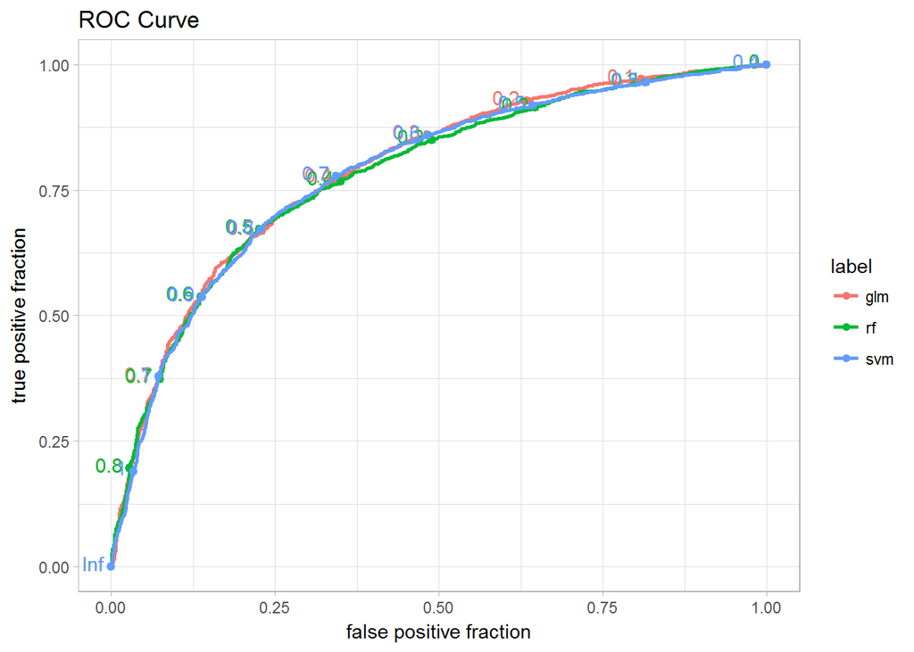

Jak widać, każdy model dopasowuje się równie dobrze i na podstawie samej krzywej ROC nie jesteśmy w stanie wybrać najlepszego.

## 5.2 PDP, ALE

## 5.3 ExternalRiskEstimate

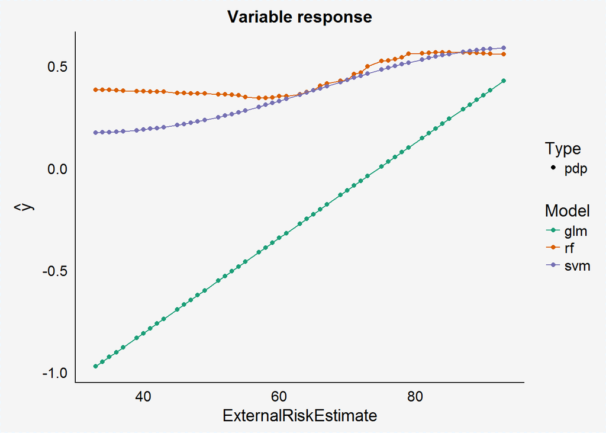

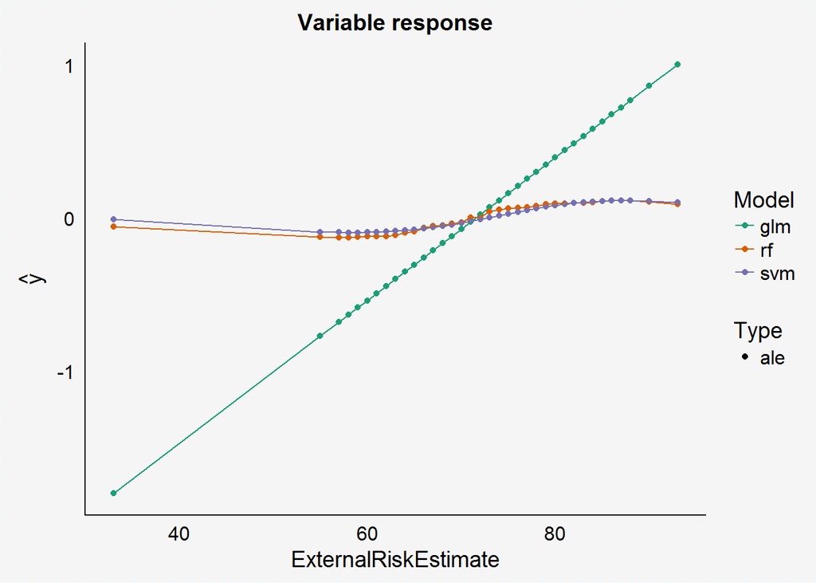

## 5.4 MSinceOldestTradeOpen

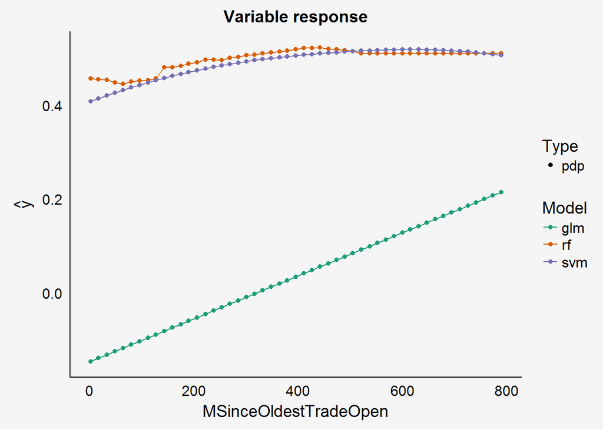

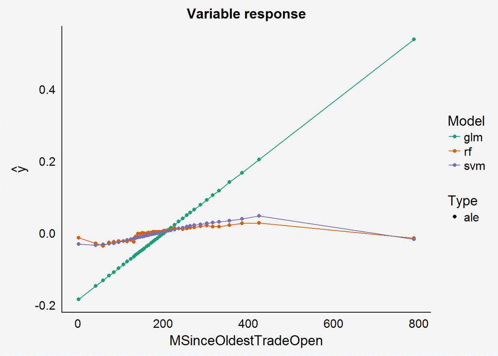

## 5.5 MSinceMostRecentTradeOpen

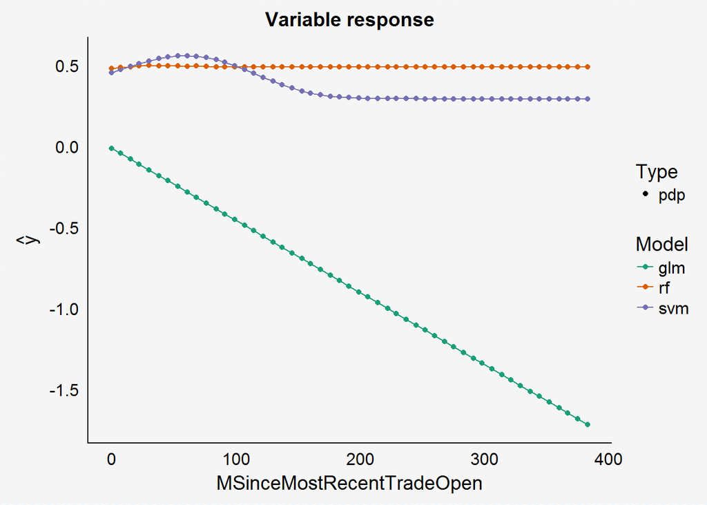

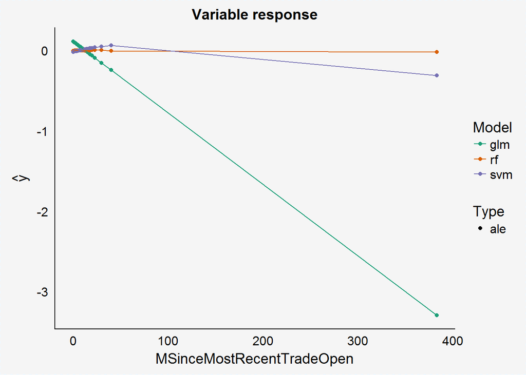